# TRoLR Outlier Report - HG002

2026-04-30

*Outliers identified in TRoLR analysis pipeline. May not reflect all repeat expansions in the sample. Please refer to the full TRoLR pipeline outputs for comprehensive variant data. Not indented for clinical use.*

## Summary

**Outlier type summary:**

| Type | Count |
| --- | --- |
| Exon | 1 |
| 5'UTR | 1 |
| 3'UTR | 0 |
| Intron (count ≥ 100) | 1 |
| Intron (count &lt; 100) | 11 |
| Other/Unclassified | 20 |
| Short motifs (&lt;3 bp) | 19 |
| Pathogenic calls | 0 |

## Pathogenic calls

*Pathogenic calls count the number of a pathogenic-associated motif regardless of interruption, resulting in potential false positives. If a count is at or near the pathogenic minimum, please consult the genotype files.*

No pathogenic calls found.

## Outliers

### Exon outliers

|  | locus | sample | hp | motif | count | n | n_unique_lengths | mean | median | per99 | sd | cv | min | max | gene | feature | status | OMIM | phenotype | diff | motif_len |
| --- | --- | --- | --- | --- | --- | --- | --- | --- | --- | --- | --- | --- | --- | --- | --- | --- | --- | --- | --- | --- | --- |
| 24 | chr9:87920617-87920625 | HG002 | hp2 | CTC | 4 | 927 | 1 | 3 | 3 | 3 | 0 | 0 | 3 | 3 | SPATA31C1 | exon | CATALOG | . | . | 1 | 3 |

#### Distribution plots

Control population distributions with sample value (red dashed line):

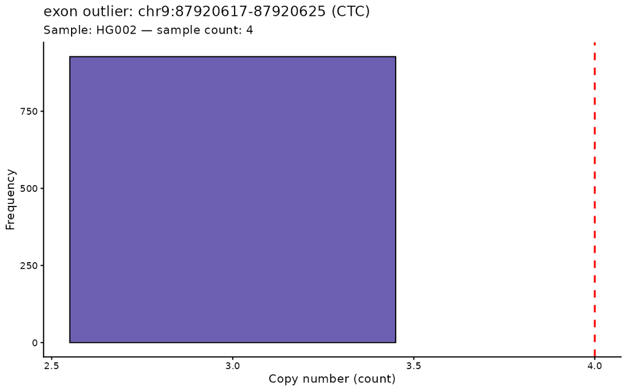

### 5’UTR outliers

|  | locus | sample | hp | motif | count | n | n_unique_lengths | mean | median | per99 | sd | cv | min | max | gene | feature | status | OMIM | phenotype | diff | motif_len |
| --- | --- | --- | --- | --- | --- | --- | --- | --- | --- | --- | --- | --- | --- | --- | --- | --- | --- | --- | --- | --- | --- |
| 3 | chr9:81689477-81689488 | HG002 | hp2 | CTG | 11 | 931 | 1 | 4 | 4 | 4 | 0 | 0 | 4 | 4 | TLE1 | 5UTR | CATALOG | . | . | 7 | 3 |

#### Distribution plots

Control population distributions with sample value (red dashed line):

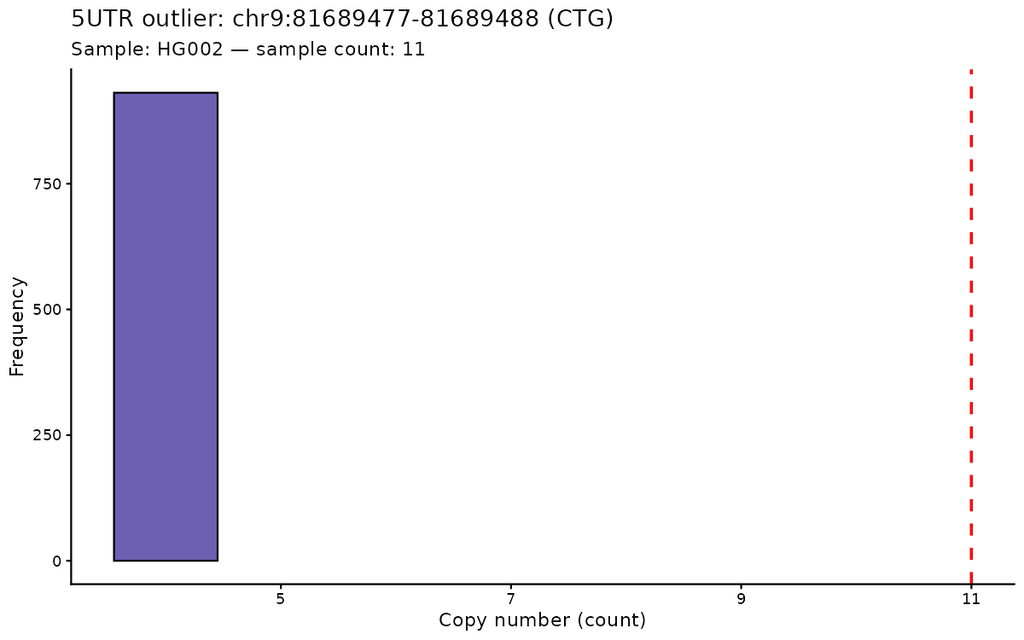

### 3’UTR outliers

No 3’UTR outliers found.

### Intron outliers (count ≥ 100)

*Note: Only showing intron outliers with count ≥ 100. Lower count intron outliers are in the Other/Unclassified section.*

|  | locus | sample | hp | motif | count | n | n_unique_lengths | mean | median | per99 | sd | cv | min | max | gene | feature | status | OMIM | phenotype | diff | motif_len |
| --- | --- | --- | --- | --- | --- | --- | --- | --- | --- | --- | --- | --- | --- | --- | --- | --- | --- | --- | --- | --- | --- |
| 1 | chr9:87575214-87575274 | HG002 | hp1 | AATAA | 125 | 934 | 23 | 9.8469 | 10 | 17 | 11.8219 | 1.2006 | 4 | 192 | DAPK1 | intron | CATALOG | . | . | 108 | 5 |

#### Distribution plots

Control population distributions with sample value (red dashed line):

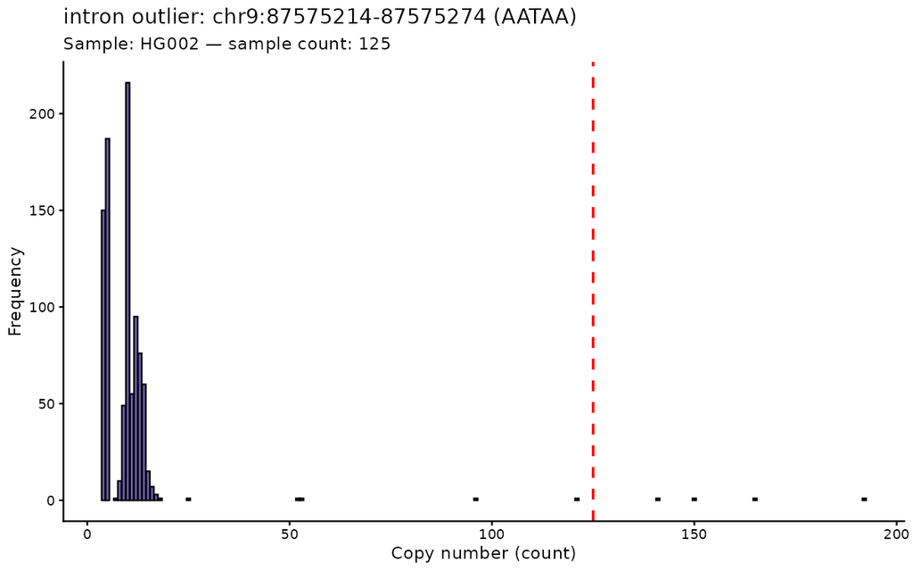

### Other/Unclassified outliers

*Includes non-annotated outliers and intron outliers with count < 100.*

|  | locus | sample | hp | motif | count | n | n_unique_lengths | mean | median | per99 | sd | cv | min | max | gene | feature | status | OMIM | phenotype | diff | motif_len |
| --- | --- | --- | --- | --- | --- | --- | --- | --- | --- | --- | --- | --- | --- | --- | --- | --- | --- | --- | --- | --- | --- |
| 4 | chr9:86758331-86758469 | HG002 | hp2 | ATCT | 21 | 936 | 10 | 11.0438 | 11 | 14 | 1.2981 | 0.1175 | 5 | 16 | . | . | CATALOG | . | . | 7 | 4 |
| 7 | chr9:87105953-87106045 | HG002 | hp1 | GAGA | 5 | 928 | 1 | 3 | 3 | 3 | 0 | 0 | 3 | 3 | . | . | CATALOG | . | . | 2 | 4 |
| 8 | chr9:95407662-95407837 | HG002 | hp2 | CTTT | 6 | 934 | 2 | 4.0011 | 4 | 4 | 0.0327 | 0.0082 | 4 | 5 | . | . | CATALOG | . | . | 2 | 4 |
| 9 | chr9:78118687-78118733 | HG002 | hp2 | AGAAA | 4 | 934 | 2 | 3.0032 | 3 | 3 | 0.0566 | 0.0188 | 3 | 4 | . | . | CATALOG | . | . | 1 | 5 |
| 10 | chr9:81856985-81857020 | HG002 | hp2 | AAAAAAGAA | 2 | 928 | 1 | 1 | 1 | 1 | 0 | 0 | 1 | 1 | . | . | CATALOG | . | . | 1 | 9 |
| 11 | chr9:83220251-83220348 | HG002 | hp1 | GGACTCGCTTCTGCGCTAATGGGGATCGCCATAGCTTCAATGACTATAAAATCAGGACCTGTCGTATCTGCATAGCCTGTCTTAGAGGTTTACG | 3 | 432 | 3 | 1.0255 | 1 | 2 | 0.219 | 0.2136 | 1 | 3 | . | . | CATALOG | . | . | 1 | 94 |
| 16 | chr9:85392642-85392709 | HG002 | hp1 | TTTT | 3 | 284 | 3 | 2.0176 | 2 | 2 | 0.1771 | 0.0878 | 2 | 4 | . | . | CATALOG | . | . | 1 | 4 |
| 17 | chr9:85392642-85392709 | HG002 | hp2 | TTTT | 3 | 284 | 3 | 2.0176 | 2 | 2 | 0.1771 | 0.0878 | 2 | 4 | . | . | CATALOG | . | . | 1 | 4 |
| 18 | chr9:86368526-86368661 | HG002 | hp2 | CCTT | 9 | 929 | 2 | 8.0011 | 8 | 8 | 0.0328 | 0.0041 | 8 | 9 | . | . | CATALOG | . | . | 1 | 4 |
| 19 | chr9:86421880-86421916 | HG002 | hp2 | AGAAAA | 3 | 933 | 1 | 2 | 2 | 2 | 0 | 0 | 2 | 2 | . | . | CATALOG | . | . | 1 | 6 |

[output cut: 21 more lines]

### Short motifs (<3 bp)

These short motif outliers are reported separately and do not have associated distribution plots.

|  | locus | sample | hp | motif | count | n | n_unique_lengths | mean | median | per99 | sd | cv | min | max | gene | feature | status | OMIM | phenotype | diff | motif_len |
| --- | --- | --- | --- | --- | --- | --- | --- | --- | --- | --- | --- | --- | --- | --- | --- | --- | --- | --- | --- | --- | --- |
| 1 | chr9:79107196-79107312 | HG002 | hp2 | AT | 29 | 483 | 12 | 19.3168 | 19 | 22 | 1.7174 | 0.0889 | 14 | 26 | . | . | CATALOG | . | . | 7 | 2 |
| 2 | chr9:95438883-95438892 | HG002 | hp2 | CA | 8 | 934 | 1 | 5 | 5 | 5 | 0 | 0 | 5 | 5 | . | . | CATALOG | . | . | 3 | 2 |
| 3 | chr9:77660768-77660785 | HG002 | hp2 | CA | 10 | 938 | 3 | 8.7409 | 9 | 9 | 0.4477 | 0.0512 | 8 | 10 | . | . | CATALOG | . | . | 1 | 2 |
| 4 | chr9:77738312-77738337 | HG002 | hp2 | AC | 12 | 932 | 4 | 10.573 | 11 | 11 | 0.52 | 0.0492 | 10 | 13 | GNAQ | intron | CATALOG | 600998 | Capillary malformations, congenital, 1, somatic, mosaic, 163000 (3)\| Sturge-Weber syndrome, somatic, mosaic, 185300 (3) | 1 | 2 |
| 5 | chr9:78715434-78715475 | HG002 | hp2 | AT | 13 | 937 | 7 | 10.5486 | 11 | 12 | 0.7202 | 0.0683 | 6 | 13 | . | . | CATALOG | . | . | 1 | 2 |
| 6 | chr9:79559098-79559126 | HG002 | hp2 | GT | 12 | 934 | 2 | 11.0032 | 11 | 11 | 0.0566 | 0.0051 | 11 | 12 | . | . | CATALOG | . | . | 1 | 2 |
| 7 | chr9:79649272-79649302 | HG002 | hp2 | AC | 18 | 935 | 8 | 15.0824 | 15 | 17 | 0.9231 | 0.0612 | 10 | 19 | TLE4 | intron | CATALOG | . | . | 1 | 2 |
| 8 | chr9:80790661-80790670 | HG002 | hp2 | TC | 6 | 933 | 1 | 5 | 5 | 5 | 0 | 0 | 5 | 5 | . | . | CATALOG | . | . | 1 | 2 |
| 9 | chr9:81717373-81717408 | HG002 | hp2 | GA | 3 | 933 | 2 | 2.0021 | 2 | 2 | 0.0462 | 0.0231 | 2 | 3 | . | . | CATALOG | . | . | 1 | 2 |
| 10 | chr9:84053853-84053902 | HG002 | hp1 | GT | 28 | 932 | 13 | 22.4614 | 25 | 27 | 4.2037 | 0.1872 | 13 | 29 | . | . | CATALOG | . | . | 1 | 2 |

[output cut: 9 more lines]

*Report generated on 2026-04-30 for sample HG002*